# Note_Book_Final

```python
import pandas as pd
import matplotlib.pyplot as plt
import seaborn as sns
file_path = r"C:\Users\hp\Desktop\cve_anssi_enriched.csv"
df = pd.read_csv(file_path, sep=";", decimal=",")
```

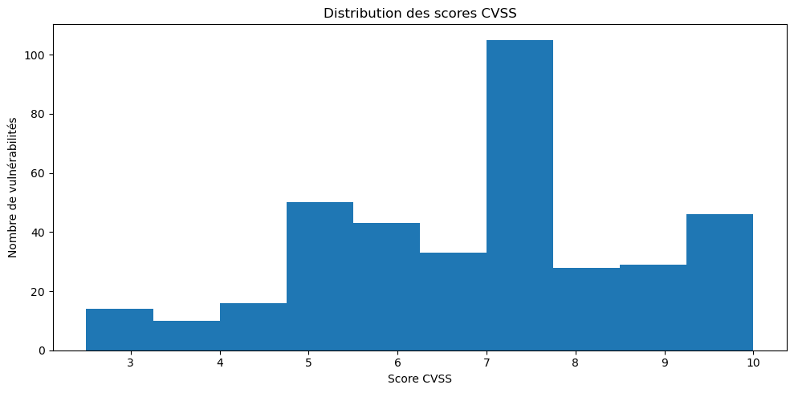

```python
plt.figure(figsize=(10, 5))
plt.hist(df["Score CVSS"].dropna(), bins=10)
plt.title("Distribution des scores CVSS")
plt.xlabel("Score CVSS")
plt.ylabel("Nombre de vulnérabilités")
plt.tight_layout()
plt.show()
```

On peut constater que la marjoriter des vulnérabilités présentent dans la database ont un score comprit entre 5 et 10 avec un pique à 7 donc dans un seuil de vulnérabilité élevée. On peut en déduire que la database comprent beaucoup de vulnérabilité qu'un service de sécurité doit resoudre en priorité

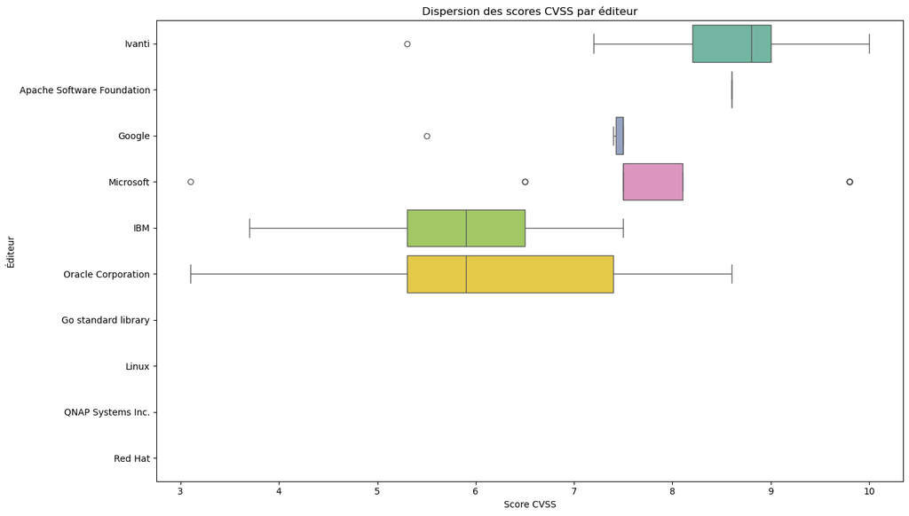

```python
plt.figure(figsize=(14, 8))
top_10_vendors = df["Éditeur/Vendor"].value_counts().head(10).index

df_top_vendors = df[df["Éditeur/Vendor"].isin(top_10_vendors)].copy()
vendor_order = df_top_vendors.groupby("Éditeur/Vendor")["Score CVSS"].median().sort_values(ascending=False).index
sns.boxplot(data=df_top_vendors, y="Éditeur/Vendor", x="Score CVSS",order=vendor_order, palette="Set2")
plt.title("Dispersion des scores CVSS par éditeur")
plt.xlabel("Score CVSS")
plt.ylabel("Éditeur")
plt.tight_layout()
plt.show()
```

Là on peut voir les éditeurs qui présentent les vulnérabilités les plus inquétiant (ivanti, Apache, Google, Microsoft) donc ce sera eux qu'il faut contacter d'abord pour qu'il regle les problemes REMARQUE: Pour de la lisibilité on se limite aux 10 valeur les plus fréquentes

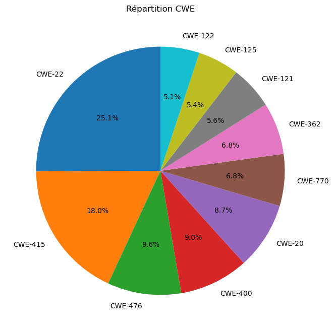

```python
plt.figure(figsize=(8, 8))
df["Type CWE"].value_counts().head(10).plot(kind="pie", autopct="%1.1f%%", startangle=90)
plt.title("Répartition CWE")
plt.ylabel("")
plt.show()
```

La Majorité des vunérabilié sont des CWE-22(Limitation incorrecte pour un nom de chemin à un annuaire restreint) et CWE-415(libere deux fois sur la même adresse mémoire.) REMARQUE: Pour de la lisibilité on se limite aux 10 valeur les plus fréquentes

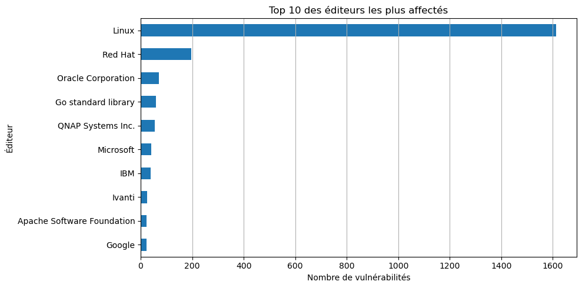

```python
vendors = df["Éditeur/Vendor"].dropna().str.split(",").explode()
vendors = vendors.str.strip()
vendors = vendors[vendors != ""]
plt.figure(figsize=(10, 5))
top_vendors = vendors.value_counts().head(10)
top_vendors.plot(kind="barh")
plt.title("Top 10 des éditeurs les plus affectés")
plt.xlabel("Nombre de vulnérabilités")
plt.ylabel("Éditeur")
plt.gca().invert_yaxis()
plt.tight_layout()
plt.grid(axis='x')
plt.show()
```

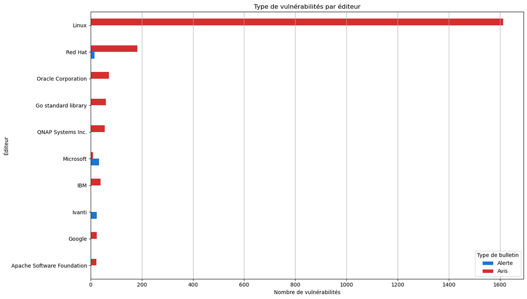

```python
plt.figure(figsize=(14, 8))
top_10_vendors = df["Éditeur/Vendor"].value_counts().head(10).index
df_top_10 = df[df["Éditeur/Vendor"].isin(top_10_vendors)].copy()
pivot_data_grouped = pd.crosstab(df_top_10["Éditeur/Vendor"], df_top_10["Type de bulletin"])
pivot_data_grouped = pivot_data_grouped.reindex(pivot_data_grouped.sum(axis=1).sort_values(ascending=True).index)
pivot_data_grouped.plot(kind="barh", color=["#1976d2", "#d32f2f"],figsize=(14, 8))
plt.title("Type de vulnérabilités par éditeur")
plt.xlabel("Nombre de vulnérabilités")
plt.ylabel("Éditeur")
plt.legend(title="Type de bulletin")
plt.grid(axis='x')
plt.tight_layout()
plt.show()
```

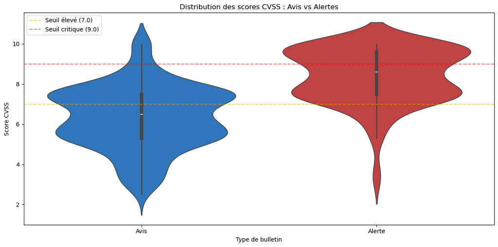

```python
plt.figure(figsize=(12, 6))
df_with_cvss = df[df["Score CVSS"].notna()].copy()
sns.violinplot(data=df_with_cvss, x="Type de bulletin", y="Score CVSS",palette=["#1976d2", "#d32f2f"], inner="box")
plt.title("Distribution des scores CVSS : Avis vs Alertes")
plt.xlabel("Type de bulletin")
plt.ylabel("Score CVSS")
plt.axhline(7, color='orange', linestyle='--', alpha=0.5, label='Seuil élevé (7.0)')
plt.axhline(9, color='red', linestyle='--', alpha=0.5, label='Seuil critique (9.0)')
plt.legend()
plt.tight_layout()
plt.show()
```

Ce graphique montre que les alertes sont en majoritées des vulnérabilité prioritaire ( depassant le seuil critique et élévée) alors que les avis répresente plus les vunérabilité sont en majorités moins urgentes

[figure not shown]

```python
df_time = df.dropna(subset=["Date de publication"]).sort_values("Date de publication")
plt.figure(figsize=(14, 14))
plt.plot(df_time["Date de publication"])
plt.title("Évolution du nombre des vulnérabilités dans le temps")
plt.xlabel("Date")
plt.ylabel("Nombre cumulé de vulnérabilités")
plt.show()
```

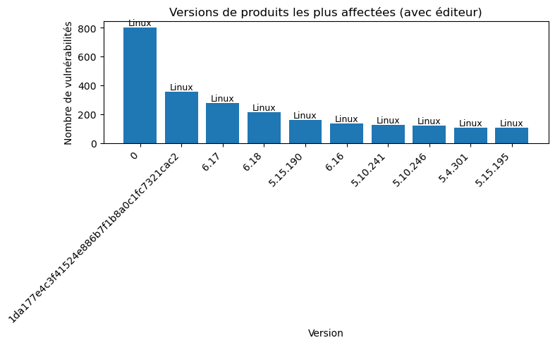

```python
temp = df[["Versions affectées", "Éditeur/Vendor"]].dropna().reset_index(drop=True)
temp = temp.assign(versions = temp["Versions affectées"].str.split(",")).explode("versions")
temp["versions"] = temp["versions"].str.strip()
temp = temp[temp["versions"] != ""]
top = (temp.groupby(["versions", "Éditeur/Vendor"]).size().reset_index(name="count").sort_values("count", ascending=False).head(10))
plt.figure(figsize=(8, 5))
plt.bar(top["versions"], top["count"])
for i, ed in enumerate(top["Éditeur/Vendor"]):
    plt.text(i, top["count"].iloc[i], ed, ha='center', va='bottom', fontsize=9)
plt.title("Versions de produits les plus affectées (avec éditeur)")
plt.xlabel("Version")
plt.ylabel("Nombre de vulnérabilités")
plt.xticks(rotation=45, ha="right")
plt.tight_layout()
plt.show()
```

Ce graphe montre les versions les plus affectées par des vulnérabilité par éditeur. Dans ce cas on constate que Linux représente est l'éditeur dont les versions sont les plus affectées par de vulnérabilité comme par exemple la version 0 de Linux est touchée par environ 800 vulnérabilité sur plus de 2000 recensées dans le fichier csv. On peut conclure que les produit Linux possède beaucoup de faille.

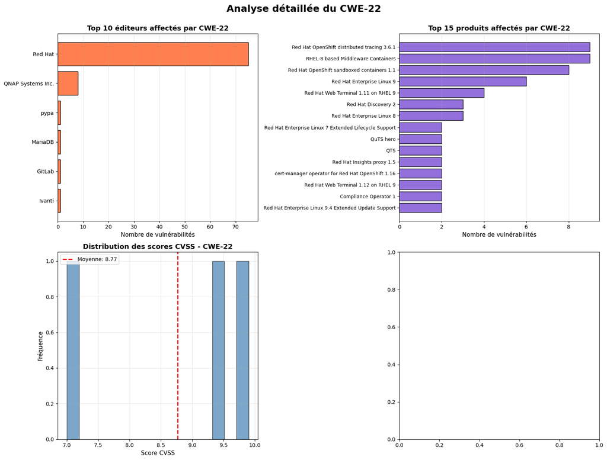

```python
cwe_choisi = "CWE-22"
df_cwe = df[df["Type CWE"] == cwe_choisi].copy()
fig, axes = plt.subplots(2, 2, figsize=(16, 12))
fig.suptitle(f"Analyse détaillée du {cwe_choisi}", fontsize=18, fontweight="bold", y=1.00)
top_vendors_cwe = df_cwe["Éditeur/Vendor"].value_counts().head(10)
axes[0, 0].barh(range(len(top_vendors_cwe)), top_vendors_cwe.values, color="coral", edgecolor="black")
axes[0, 0].set_yticks(range(len(top_vendors_cwe)))
axes[0, 0].set_yticklabels(top_vendors_cwe.index, fontsize=10)
axes[0, 0].set_title(f"Top 10 éditeurs affectés par {cwe_choisi}", fontsize=13, fontweight="bold")
axes[0, 0].set_xlabel("Nombre de vulnérabilités", fontsize=11)
axes[0, 0].invert_yaxis()
axes[0, 0].grid(axis='x', alpha=0.3)
top_products_cwe = df_cwe["Produit"].value_counts().head(15)
axes[0, 1].barh(range(len(top_products_cwe)), top_products_cwe.values, color="mediumpurple", edgecolor="black")
axes[0, 1].set_yticks(range(len(top_products_cwe)))
axes[0, 1].set_yticklabels(top_products_cwe.index, fontsize=9)
axes[0, 1].set_title(f"Top 15 produits affectés par {cwe_choisi}", fontsize=13, fontweight="bold")
axes[0, 1].set_xlabel("Nombre de vulnérabilités", fontsize=11)
axes[0, 1].invert_yaxis()
axes[0, 1].grid(axis='x', alpha=0.3)
axes[1, 0].hist(df_cwe["Score CVSS"].dropna(), bins=15, color="steelblue", edgecolor="black", alpha=0.7)
axes[1, 0].set_title(f"Distribution des scores CVSS - {cwe_choisi}", fontsize=13, fontweight="bold")
axes[1, 0].set_xlabel("Score CVSS", fontsize=11)
axes[1, 0].set_ylabel("Fréquence", fontsize=11)
axes[1, 0].axvline(df_cwe["Score CVSS"].mean(), color='red', linestyle='--', linewidth=2,
                   label=f'Moyenne: {df_cwe["Score CVSS"].mean():.2f}')
axes[1, 0].legend()
axes[1, 0].grid(alpha=0.3)

plt.tight_layout()
plt.show()
```

Ces graphes permettent de voir comment le CWE-22 affecte les editeur et leurs produits et avec quel impact. Ici ont peut voir que CWE-22 affecte en majorité l'éditeur Red Hat avec pricipale le produit Openshift et a en moyenne une sevérité élevée à critique (8.77)

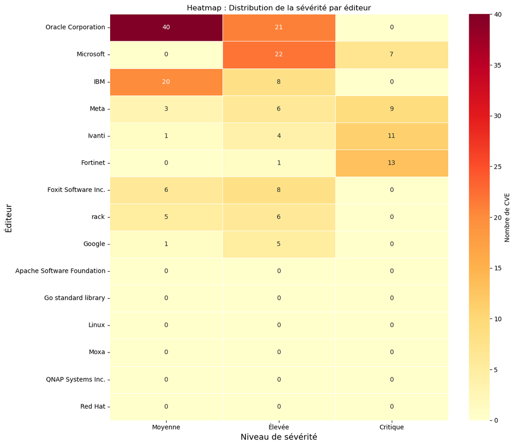

```python
top_15_vendors = df["Éditeur/Vendor"].value_counts().head(15).index
df_top_vendors_heat = df[df["Éditeur/Vendor"].isin(top_15_vendors)].copy()
severity_order = ["Faible", "Moyenne", "Élevée", "Critique"]
heatmap_data = pd.crosstab(df_top_vendors_heat["Éditeur/Vendor"], df_top_vendors_heat["Base Severity"])
heatmap_data = heatmap_data.reindex(columns=[s for s in severity_order if s in heatmap_data.columns])
heatmap_data = heatmap_data.loc[heatmap_data.sum(axis=1).sort_values(ascending=False).index]
plt.figure(figsize=(12, 10))
sns.heatmap(heatmap_data, annot=True, fmt="d", cmap="YlOrRd", cbar_kws={'label': 'Nombre de CVE'}, linewidths=0.5)
plt.title("Heatmap : Distribution de la sévérité par éditeur")
plt.xlabel("Niveau de sévérité", fontsize=13)
plt.ylabel("Éditeur", fontsize=13)
plt.tight_layout()
plt.show()
```

Cela montre comment est distribuer de la sevérité par éditeur. Ici on constate que Oracle est l'editeur avec le plus de CVE de séverité moyenne REMARQUE: La Heatmap n'est pas cohérente avec les graphe précédent car Linux le l'éditeur le plus affecté n'a pas de valeur

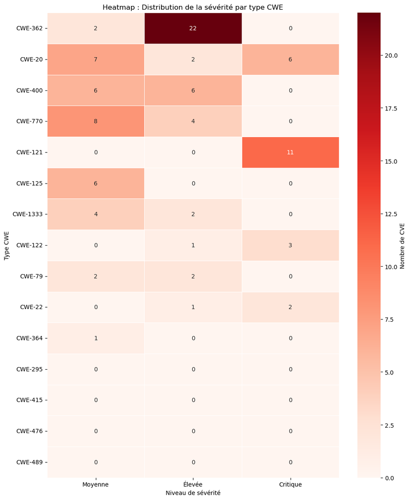

```python
top_15_cwes = df["Type CWE"].value_counts().head(15).index
df_top_cwes = df[df["Type CWE"].isin(top_15_cwes)].copy()
severity_order = ["Faible", "Moyenne", "Élevée", "Critique"]
heatmap_cwe = pd.crosstab(df_top_cwes["Type CWE"], df_top_cwes["Base Severity"])
heatmap_cwe = heatmap_cwe.reindex(columns=[s for s in severity_order if s in heatmap_cwe.columns])
heatmap_cwe = heatmap_cwe.loc[heatmap_cwe.sum(axis=1).sort_values(ascending=False).index]
plt.figure(figsize=(10, 12))
sns.heatmap(heatmap_cwe, annot=True, fmt="d", cmap="Reds",
            cbar_kws={'label': 'Nombre de CVE'}, linewidths=0.5)
plt.title("Heatmap : Distribution de la sévérité par type CWE")
plt.xlabel("Niveau de sévérité")
plt.ylabel("Type CWE")
plt.tight_layout()
plt.show()
```

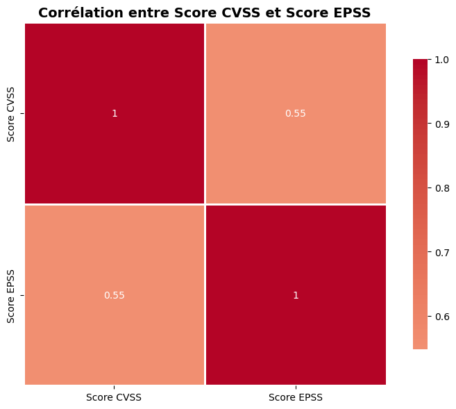

```python
for col in ["Score CVSS", "Score EPSS"]:
    df[col] = (df[col].astype(str).str.strip().str.replace(",", ".", regex=False))
    df[col] = pd.to_numeric(df[col], errors="coerce")
df_scores = df[["Score CVSS", "Score EPSS"]].dropna()

plt.figure(figsize=(8, 6))
correlation_matrix = df_scores.corr(numeric_only=True)
sns.heatmap(correlation_matrix, annot=True, cmap="coolwarm", center=0,square=True, linewidths=1, cbar_kws={"shrink": 0.8})
plt.title("Corrélation entre Score CVSS et Score EPSS", fontsize=14, fontweight="bold")
plt.tight_layout()
plt.show()
```

c'est pour montrer le lien entre le score EPPS et CVSS